# Batch jobs in R

## Tips and tricks

- shell
- path
- `.bashrc`
- Accre + GitHub

## Recommended DataCamp course

[figure not shown]

## What is the path

- The path is a list of folders that the operating system searches to find a command.
  - Windows: You can update the path by point and click
  - Linux: You can update via command line or by editing specific files
  - MacOS: Command line, but there is probably a point an click option as well. (I just don’t know.)
- If the command `Rscript` or `R` is not part of the path, you’ll need to (a) add it, or (b) provide the location of the Rscript executable

## How to check if `R` is in the path?

Run the command `R` in the shell.

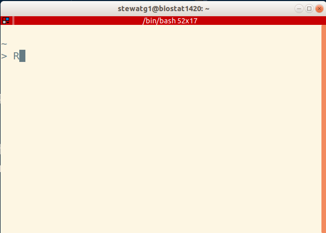

## How to check if `R` is in the path?

Did R fire-up?

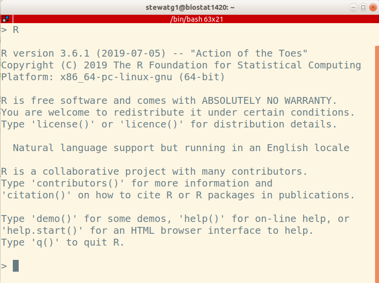

## Aside: Exit R

You can exit R with the `q()` function.

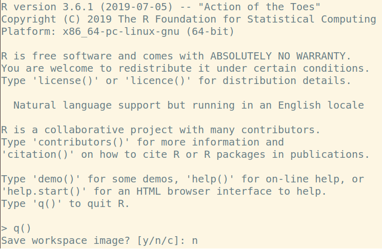

## .bashrc

- .bashrc is a simple text file named `.bashrc`
- It should be located in the home directory
- If the file does not exist, you can create it with a text editor like notepad, atom, vi, nano, etc.

## .bashrc

### What does it do?

> .bashrc is a shell script that Bash runs whenever it is started interactively. It initializes an interactive shell session. You can put any command in that file that you could type at the command prompt.  
> You put commands here to set up the shell for use in your particular environment, or to customize things to your preferences. A common thing to put in .bashrc are aliases that you want to always be available.  
> From Warren Young and Kusalananda, post on [StackExchange](https://unix.stackexchange.com/questions/129143/what-is-the-purpose-of-bashrc-and-how-does-it-work)

## Windows git bash `.bashrc` example

```r
# A hack to set the alias to the current version of R
# I think there should be an easier way to do this, so if you
# find it please let me know
# Warning: this is very hacky ... it may be easier to hard code the path
Rpath=$(REG QUERY HKLM\\SOFTWARE\\R-core\\R64 //v InstallPath)
rp2=$(echo "${Rpath}" | tr -d '\n\r' | tr -s '[:space:]')
rp3=$(echo "${rp2:58}" | sed -r -e 's|^C:|/c|' -e 's|\\|/|g' -e 's|Program Files|Program\\ Files|')

alias R=$rp3"/bin/R.exe --vanilla"
alias Rgui=$rp3"/bin/x64/Rgui.exe --vanilla"
alias Rscript=$rp3"/bin/Rscript.exe"
alias rs="C:/\"Program Files\"/RStudio/bin/rstudio.exe"
```

## MacOS and Linux

- Generally, R already on the path, so there is no need to edit `.bashrc` for that reason.

## Windows, MacOS, and Linux

- However, everyone may want to edit the `.bashrc` file to include an alias to the accre login command.

```r
alias accre="ssh USERNAME@login.accre.vanderbilt.edu";
```

Only need to type `accre` to start the login process.

## Alias for accre

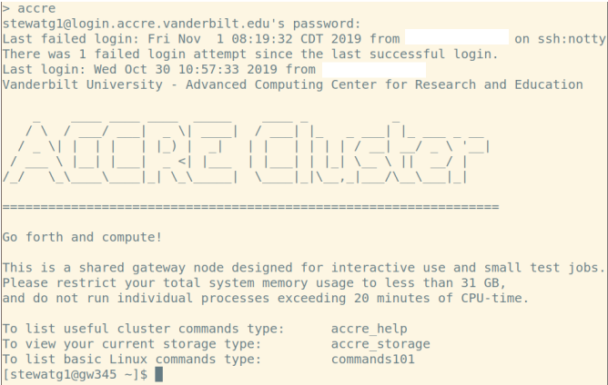

## Ready to run code in batch or on accre

## Start with an R script

```r
# Simulation for the CLT shortcut
generate_data <- function(N){rgamma(N, 3, scale = 1.5)}
analysis <- function(data){ t.test(data)$conf.int }
capture_mean <- function(ci, parameter_of_interest = 4.5){
  1*(ci[1] <= parameter_of_interest & parameter_of_interest <= ci[2])
}

coverage_probability <-
  replicate(5000, 201 %>% generate_data %>% analysis %>% capture_mean) %>%
  mean
```

## Include commands to save results

```r
results <- data.frame(
    N = 201
  , dist = "gamma(3, 1.5)"
  , measure = "mean"
  , method = "clt (t.test)"
  , coverage_probability = coverage_probability
  , stringsAsFactors = FALSE
)

# Perhaps save to a results folder
saveRDS(results, file = "./results/coverage_probability-01.rds")
```

## Code and results folder

[figure not shown]

## Open terminal or command line

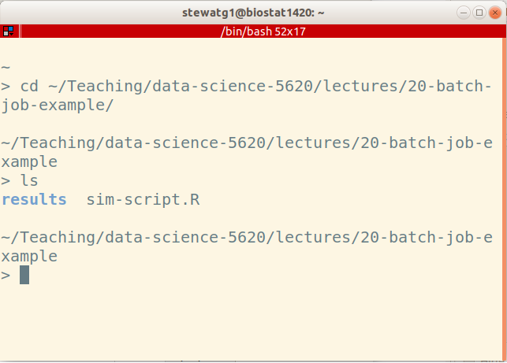

## Rscript command (if Rscript is in the path)

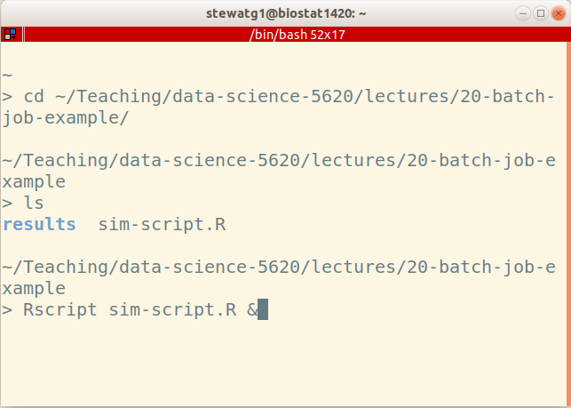

## Aside: & or no &

If you run the command without the ampersand (&), then the job stays connected to the shell. One can terminate the job by closing the shell or by typing `control + c`. (There is a Mac equivalent, but I’m not sure what it is.)

```r
Rscript sim-script.R
```

If you run the command **with** the ampersand (&), then the job runs in the background, unconnected to the shell. One can terminate the job by executing a kill command on the job id.

```r
Rscript sim-script.R &
```

## Rscript results

- Script is executed and results are stored.

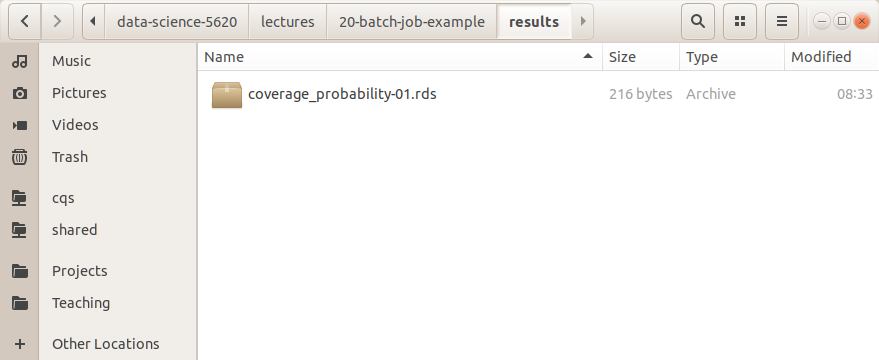

## After the simulation

- Pull results into markdown or notebook to generate tables and figures for the write-up.

## Accre

> **Recommended approach:**  
> (a) Develop your code on your personal computer in a GitHub repo.  
> (b) Make sure code works on a small number of replicates.  
> (c) If successful, push to GitHub  
> (d) Log on to accre with interactive session and pull repo  
> (e) Run small number replicates on accre, tweak as needed  
> (f) If successful, set replicates to full amount and submit a batch job.